# final_case_study

```python
# ============================================================
# TASK 1 — STATISTICS
# ============================================================

# Given values from the task description:
P_cancel = 0.24                 # Base cancellation rate
FPR = 0.04                      # False positive rate
FNR = 0.00                      # False negative rate
loss_per_cancel = 10.0          # €10 loss per cancellation
insurance_cost = 8.5            # €8.5 insurance per customer

# True Positive Rate (sensitivity)
TPR = 1 - FNR   # = 1 because FNR = 0


# ============================================================
# 1(a) — Probability customer cancels GIVEN model predicts cancellation
# ============================================================

# Bayes numerator:
numerator = TPR * P_cancel

# Probability the model predicts cancellation at all:
P_model_cancel = TPR * P_cancel + FPR * (1 - P_cancel)

P_cancel_given_model = numerator / P_model_cancel

print("1(a) Probability customer cancels given model predicts cancel:")
print(f"P(cancel | model says cancel) = {P_cancel_given_model:.4f}  ({P_cancel_given_model*100:.2f}%)")
print()

# ============================================================
# 1(b) — Should we take the insurance? Compare two strategies:
#   Strategy 1: Insure EVERY customer
#   Strategy 2: Insure ONLY customers predicted to cancel
# ============================================================

# ---- Strategy 1: Insure everyone ----
expected_loss_without_insurance = P_cancel * loss_per_cancel
expected_cost_with_insurance = insurance_cost

print("1(b) Strategy 1: Insure every customer")
print(f"Expected loss without insurance = {expected_loss_without_insurance:.2f} €")
print(f"Insurance cost per customer =     {expected_cost_with_insurance:.2f} €")

if expected_cost_with_insurance < expected_loss_without_insurance:
    print("→ Decision: INSURE everyone\n")
else:
    print("→ Decision: DO NOT insure everyone\n")


# ---- Strategy 2: Insure only model-flagged customers ----
# For customers where model predicts 'cancel':
expected_loss_flagged = P_cancel_given_model * loss_per_cancel
insurance_flagged = insurance_cost

print("1(b) Strategy 2: Insure ONLY customers flagged by the model")
print(f"Expected loss for a flagged customer = {expected_loss_flagged:.3f} €")
print(f"Insurance cost for flagged customer   = {insurance_flagged:.3f} €")

if insurance_flagged < expected_loss_flagged:
    print(f"→ Decision: INSURE flagged customers (save: {expected_loss_flagged - insurance_flagged:.3f} €)")
else:
    print("→ Decision: DO NOT insure flagged customers")
```

```
1(a) Probability customer cancels given model predicts cancel:
P(cancel | model says cancel) = 0.8876  (88.76%)

1(b) Strategy 1: Insure every customer
Expected loss without insurance = 2.40 €
Insurance cost per customer =     8.50 €
→ Decision: DO NOT insure everyone

1(b) Strategy 2: Insure ONLY customers flagged by the model
Expected loss for a flagged customer = 8.876 €
Insurance cost for flagged customer   = 8.500 €
→ Decision: INSURE flagged customers (save: 0.376 €)
```

Using the overall cancellation probability (24%), the expected loss per customer is 2.40€, which is far below the 8.50€ insurance premium, so we should not buy universal insurance.

If, hypothetically, we were allowed to insure only customers predicted to cancel by our model, then for those customers the expected loss is about 8.88€, slightly above the 8.50€ premium, so it would be profitable to insure that high-risk segment.

```python
# ==========================================================
# TASK 2
# ============================================================

import pandas as pd
import numpy as np
import matplotlib.pyplot as plt
import seaborn as sns
import networkx as nx
from itertools import combinations
from pandas.plotting import parallel_coordinates

plt.style.use("ggplot")
```

```python
# ============================================================
# 1. Load data
# ============================================================
orders = pd.read_parquet("orders_data.parquet")
products = pd.read_parquet("products_data.parquet")
```

```python
# ============================================================
# 2. Basic EDA + cleaning
# ============================================================
print("=== ORDERS HEAD ===")
print(orders.head())
print("\n=== PRODUCTS HEAD ===")
print(products.head())

print("\n=== ORDERS INFO ===")
print(orders.info())
print("\n=== PRODUCTS INFO ===")
print(products.info())

print("\n=== ORDERS NULLS ===")
print(orders.isna().sum())
print("\n=== PRODUCTS NULLS ===")
print(products.isna().sum())

# Deduplicate products by title (some titles appear multiple times)
products_unique = products.drop_duplicates(subset=["product_title"]).copy()

# Parse date columns in orders (strip ' UTC' and convert to datetime)
date_cols = ["processed_at", "created_at", "cancelled_at", "first_date_order"]
for col in date_cols:
    if col in orders.columns:
        orders[col] = pd.to_datetime(
            orders[col].str.replace(" UTC", "", regex=False),
            errors="coerce"
        )

# Create order_date and order_month (normalized to first day of month)
orders["order_date"] = pd.to_datetime(orders["processed_at"].dt.date)
orders["order_month"] = orders["order_date"].values.astype("datetime64[M]")

# Basic date sanity checks
print("\nOrder date range:", orders["order_date"].min(), "->", orders["order_date"].max())
print("Order month range:", orders["order_month"].min(), "->", orders["order_month"].max())
```

```
=== ORDERS HEAD ===
  billing_address_country billing_address_zip  customer_id  order_number  \
0                 Germany               81371  43539353630             1
1                 Germany               12045  43973434860             2
2                 Germany                8315  46668580946             3
3                 Germany               91301  40345377076             4
4                 Germany                8577  33355469588             5

   total_discounts cancel_reason             processed_at  total_weight  \
0                0      customer  2019-12-03 13:08:32 UTC             0
1                0      customer  2019-12-04 09:23:09 UTC             0
2                0          None  2019-12-06 07:58:34 UTC             0
3                0          None  2019-12-06 18:29:03 UTC             0
4                0          None  2019-12-08 18:16:40 UTC             0

              cancelled_at               created_at  \
0  2019-12-04 09:00:44 UTC  2019-12-03 13:08:33 UTC
1  2020-01-20 14:55:25 UTC  2019-12-04 09:23:09 UTC
2                     None  2019-12-06 07:58:34 UTC
3                     None  2019-12-06 18:29:04 UTC
4                     None  2019-12-08 18:16:40 UTC

                            product_items         first_date_order
0  Golf_set_with_caddy_shoes_and_50_balls  2019-12-03 13:08:33 UTC
1  Golf_set_with_caddy_shoes_and_50_balls  2019-12-04 09:23:09 UTC
2  Golf_set_with_caddy_shoes_and_50_balls  2019-12-06 07:58:34 UTC
3  Golf_set_with_caddy_shoes_and_50_balls  2019-12-06 18:29:04 UTC
4  Golf_set_with_caddy_shoes_and_50_balls  2019-12-08 18:16:40 UTC

=== PRODUCTS HEAD ===
  product_type  product_price product_category         product_title
0        glove          39.99             golf  Golf_glove_left_hand
1   golf_balls          99.99             golf        Golf_balls_200
2   golf_balls          99.99             golf        Golf_balls_200
3   golf_balls          59.99             golf        Golf_balls_100
4   golf_balls          59.99             golf        Golf_balls_100

=== ORDERS INFO ===
<class 'pandas.core.frame.DataFrame'>
RangeIndex: 189140 entries, 0 to 189139
```

[output cut: 42 more lines]

```
cancelled_at               187554
created_at                      0
product_items                   0
first_date_order                0
dtype: int64

=== PRODUCTS NULLS ===
product_type        0
product_price       0
product_category    0
product_title       0
dtype: int64

Order date range: 2019-12-03 00:00:00 -> 2021-03-08 00:00:00
Order month range: 2019-12-01 00:00:00 -> 2021-03-01 00:00:00
```

```python
# ============================================================
# 3. Feature engineering: order-lines + revenue
# ============================================================
# Lookup table for product info
product_lookup = (
    products_unique
    .set_index("product_title")[["product_price", "product_category", "product_type"]]
)

def explode_order_products(df_orders: pd.DataFrame,
                           lookup: pd.DataFrame) -> pd.DataFrame:
    """
    Expand orders into one row per product line item.
    product_items is a comma-separated list of product_title.
    """
    records = []
    for _, row in df_orders.iterrows():
        items = [s.strip() for s in str(row["product_items"]).split(",")]
        for title in items:
            if title in lookup.index:
                rec = lookup.loc[title]
                price = rec["product_price"]
                category = rec["product_category"]
                ptype = rec["product_type"]
            else:
                # In case a title is missing in products table
                price = np.nan
                category = None
                ptype = None

            records.append(
                {
                    "order_number": row["order_number"],
                    "customer_id": row["customer_id"],
                    "order_date": row["order_date"],
                    "order_month": row["order_month"],
                    "product_title": title,
                    "product_price": price,
                    "product_category": category,
                    "product_type": ptype,
                }
            )
    return pd.DataFrame(records)

order_lines = explode_order_products(orders, product_lookup)

print("\n=== ORDER LINES HEAD ===")
print(order_lines.head())
print("\n=== ORDER LINES NULLS ===")
print(order_lines.isna().sum())

# Order-level revenue
order_revenue = (
    order_lines
    .groupby("order_number")["product_price"]
    .sum()
    .rename("order_revenue")
)

orders = orders.merge(order_revenue, on="order_number", how="left")

print("\nOrder revenue summary:")
print(orders["order_revenue"].describe())
```

```
=== ORDER LINES HEAD ===
   order_number  customer_id order_date order_month  \
0             1  43539353630 2019-12-03  2019-12-01
1             2  43973434860 2019-12-04  2019-12-01
2             3  46668580946 2019-12-06  2019-12-01
3             4  40345377076 2019-12-06  2019-12-01
4             5  33355469588 2019-12-08  2019-12-01

                            product_title  product_price product_category  \
0  Golf_set_with_caddy_shoes_and_50_balls         259.99             golf
1  Golf_set_with_caddy_shoes_and_50_balls         259.99             golf
2  Golf_set_with_caddy_shoes_and_50_balls         259.99             golf
3  Golf_set_with_caddy_shoes_and_50_balls         259.99             golf
4  Golf_set_with_caddy_shoes_and_50_balls         259.99             golf

     product_type
0  mixed_set_golf
1  mixed_set_golf
2  mixed_set_golf
3  mixed_set_golf
4  mixed_set_golf

=== ORDER LINES NULLS ===
order_number        0
customer_id         0
order_date          0
order_month         0
product_title       0
product_price       0
product_category    0
product_type        0
dtype: int64

Order revenue summary:
count    189140.000000
mean        285.229512
std         158.444418
min           0.200000
25%         199.990000
50%         259.990000
75%         309.970000
max        4059.880000
Name: order_revenue, dtype: float64
```

# ============================================================

# TASK 2a — Customer Cohort Analysis

# ============================================================

```
=== Cohort Retention Matrix (head) ===
cohort_index   0         1         2         3         4         5         6   \
cohort_month
2019-12-01    1.0  0.033333  0.033333  0.050000       NaN  0.033333  0.033333
2020-01-01    1.0  0.010508  0.015866  0.013345  0.026794  0.019334  0.017653
2020-02-01    1.0  0.018272  0.014389  0.027712  0.020556  0.018424  0.017815
2020-03-01    1.0  0.011709  0.028127  0.016900  0.018349  0.015331  0.015814
2020-04-01    1.0  0.014786  0.017061  0.016720  0.017971  0.017288  0.017061

cohort_index        7         8         9         10        11        12  \
cohort_month
2019-12-01    0.033333       NaN  0.016667  0.016667  0.033333       NaN
2020-01-01    0.017442  0.017337  0.015656  0.021856  0.016392  0.018283
2020-02-01    0.018424  0.015303  0.019414  0.017358  0.019185  0.017054
2020-03-01    0.015572  0.022332  0.017866  0.020642  0.017866  0.006639
2020-04-01    0.021383  0.017857  0.019677  0.018198  0.007166       NaN

cohort_index        13        14
cohort_month
2019-12-01         NaN  0.016667
2020-01-01    0.017337  0.008406
2020-02-01    0.007766       NaN
2020-03-01         NaN       NaN
2020-04-01         NaN       NaN

=== Cohort Purchase Count (avg orders per customer) ===
cohort_index        0         1         2         3         4         5   \
cohort_month
2019-12-01    1.000000  1.000000  1.000000  2.000000       NaN  1.500000
2020-01-01    1.003467  1.020000  1.006623  1.015748  1.031373  1.010870
2020-02-01    1.005710  1.025000  1.005291  1.041209  1.177778  1.024793
2020-03-01    1.007605  1.030928  1.021459  1.028571  1.026316  1.023622
2020-04-01    1.004322  1.030769  1.013333  1.013605  1.012658  1.032895

cohort_index        6         7         8         9         10        11  \
cohort_month
2019-12-01    1.000000  1.000000       NaN  1.000000  2.000000  1.000000
2020-01-01    1.041667  1.030120  1.018182  1.013423  1.100962  1.057692
2020-02-01    1.017094  1.066116  1.029851  1.027451  1.057018  1.055556
2020-03-01    1.053435  1.000000  1.059459  1.047297  1.087719  1.074324
2020-04-01    1.040000  1.053191  1.044586  1.023121  1.068750  1.047619

cohort_index        12        13      14
cohort_month
2019-12-01         NaN       NaN  1.0000
2020-01-01    1.051724  1.084848  1.0125
2020-02-01    1.035714  1.029412     NaN
2020-03-01    1.018182       NaN     NaN
2020-04-01         NaN       NaN     NaN

=== Average Retention Curve (head) ===
cohort_index
0    1.000000
1    0.032250
2    0.041248
3    0.042704
4    0.046915
Name: retention_rate, dtype: float64
```

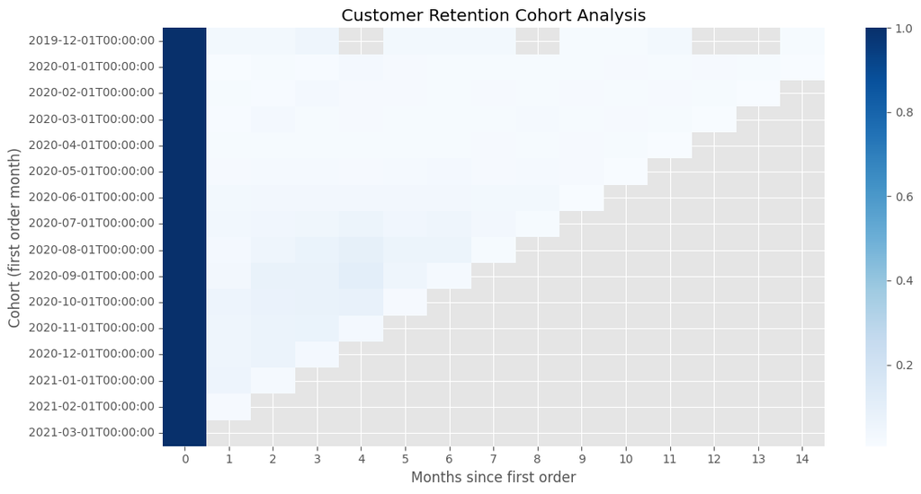

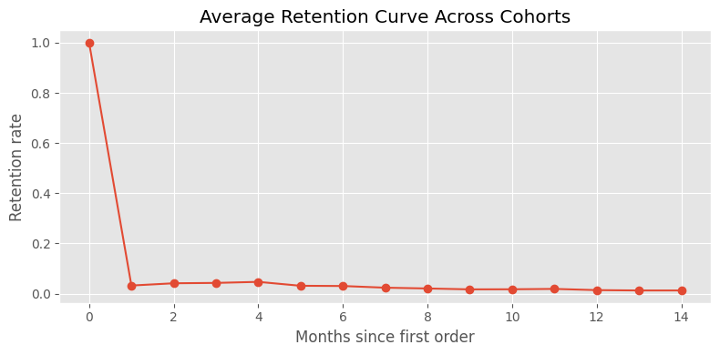

```python
# ============================================================
# 4. Cohort setup (Customer Retention Cohort Analysis)
# ============================================================
# Cohort = first order month per customer
orders["cohort_month"] = (
    orders.groupby("customer_id")["order_month"]
    .transform("min")
)

def get_month_diff(d1: pd.Series, d2: pd.Series) -> pd.Series:
    """Difference in months between two Timestamps (d1 - d2)."""
    return (d1.dt.year - d2.dt.year) * 12 + (d1.dt.month - d2.dt.month)

# Cohort index (0,1,2,... months since first order)
orders["cohort_index"] = get_month_diff(orders["order_month"], orders["cohort_month"])

# One row per customer + month for cohort calculations
cohort_data = (
    orders[["customer_id", "cohort_month", "order_month", "cohort_index"]]
    .drop_duplicates()
)

# Cohort sizes (customers in period 0)
cohort_sizes = (
    cohort_data[cohort_data["cohort_index"] == 0]
    .groupby("cohort_month")["customer_id"]
    .nunique()
    .rename("cohort_size")
)

# Retention counts by cohort & period
retention_counts = (
    cohort_data
    .groupby(["cohort_month", "cohort_index"])["customer_id"]
    .nunique()
    .rename("n_customers")
    .reset_index()
)

# Add cohort sizes and compute retention rate
retention = retention_counts.merge(cohort_sizes, on="cohort_month", how="left")
retention["retention_rate"] = retention["n_customers"] / retention["cohort_size"]

# Retention matrix for heatmap: cohorts x months since first order
retention_pivot = retention.pivot_table(
    index="cohort_month",
    columns="cohort_index",
    values="retention_rate"
)

print("\n=== Cohort Retention Matrix (head) ===")
print(retention_pivot.head())

# ----------------   Customer Cohort Purchase Count   ----------------
orders_per_customer = (
    orders
    .groupby(["customer_id", "cohort_month", "cohort_index"])["order_number"]
    .nunique()
    .reset_index(name="n_orders")
)

cohort_purchase = (
    orders_per_customer
    .groupby(["cohort_month", "cohort_index"])["n_orders"]
    .mean()
    .rename("avg_orders_per_customer")
    .unstack("cohort_index")
)

print("\n=== Cohort Purchase Count (avg orders per customer) ===")
print(cohort_purchase.head())

# ----------------   Average Retention Curve Across Cohorts   ----------------
avg_retention_curve = (
    retention
    .groupby("cohort_index")["retention_rate"]
    .mean()
)

print("\n=== Average Retention Curve (head) ===")
print(avg_retention_curve.head())

# ----------------   PLOTS: Cohort heatmap + avg retention curve   ----------------
plt.figure(figsize=(12, 6))
sns.heatmap(
    retention_pivot,
    annot=False,
    fmt=".0%",
    cmap="Blues"
)
plt.title("Customer Retention Cohort Analysis")
plt.ylabel("Cohort (first order month)")
plt.xlabel("Months since first order")
plt.tight_layout()
plt.show()

plt.figure(figsize=(8, 4))
avg_retention_curve.plot(marker="o")
plt.title("Average Retention Curve Across Cohorts")
plt.xlabel("Months since first order")
plt.ylabel("Retention rate")
plt.tight_layout()
plt.show()
```

Most customers behave like one-time purchasers. Very small percentage form a loyal customer base.